# Hierarchical Data: the data.tree package in R

# Plotting

See https://graphviz.gitlab.io/_pages/doc/info/attrs.html for more information on the styling of *data.tree* plots.

See also http://www.bioconductor.org/packages/release/bioc/vignettes/Rgraphviz/inst/doc/newRgraphvizInterface.pdf.

Plotting of *data.tree* objects using the *plot()* function in R calls the *render_graph()* function from the *DiagrammeR* package.

Run *?DiagrammeR::render_graph* in console for more information.

Here are some example plots of our tree:

```r
SetGraphStyle( acme,
               bgcolor = "black"    # make the treeplot have a black background
              )
SetNodeStyle( acme,
              fontcolor = "white",    # make text in nodes to white
              color = "white"         # make node outlines white
            )
SetEdgeStyle( acme,
              color = "white"        # make edges (arrows) white
            )

plot( acme,
      width = 900    # specify width in pixels
    )
```

[interactive chart not shown]

```r
plot( acme,
      layout = "nicely"
    )
```

[interactive chart not shown]

```r
plot( acme, layout = "fr" )
```

[interactive chart not shown]

We can closely control the text appearing inside the nodes using a custom function. This could just as easily be done for text on edges too. We put on each node the total cost across all of it’s children:

```r
GetNodeLabel <- function(node)
                {
                  paste0( node$name,
                          "\n",
                          "$ ",
                          format(node$cost_all, scientific = FALSE, big.mark = ",")
                        )
                }

print( acme, "cost", "sum_cost", "cost_all" )
```

```
##                           levelName    cost sum_cost cost_all
## 1  Acme Inc.                             NA  4950000  4950000
## 2   ¦--Accounting                        NA  1500000  1500000
## 3   ¦   ¦--New Software             1000000       NA  1000000
## 4   ¦   °--New Accounting Standards  500000       NA   500000
## 5   ¦--Research                          NA  2750000  2750000
## 6   ¦   ¦--New Product Line         2000000       NA  2000000
## 7   ¦   °--New Labs                  750000       NA   750000
## 8   °--IT                                NA   700000   700000
## 9       ¦--Outsource                 400000       NA   400000
## 10      ¦--Go agile                  250000       NA   250000
## 11      °--Switch to R                50000       NA    50000
```

```r
SetNodeStyle( acme,
              label = GetNodeLabel,
              fontname = "helvetica",
              fontcolor = "white",    # make text in nodes to white
              color = "white"         # make node outlines white
            )

plot( acme,
      width = 900
    )
```

[interactive chart not shown]

We can change the direction/orientation with the *rankdir* argument:

```r
SetGraphStyle( acme,
               bgcolor = "black",    # make the treeplot have a black background
              rankdir = "LR"
             )
plot( acme )
```

[interactive chart not shown]

Here is an example where we create a function to dynamically choose the border colour of each node according to the cost:

```r
# this command displays all of the palette options in RColorBrewer:
# display.brewer.all()

# get a list of all of the cost values in the whole tree:
all_cost_values <- acme$Get('cost_all', traversal = "post-order")
all_cost_values
```

```
##             New Software New Accounting Standards               Accounting
##                  1000000                   500000                  1500000
##         New Product Line                 New Labs                 Research
##                  2000000                   750000                  2750000
##                Outsource                 Go agile              Switch to R
##                   400000                   250000                    50000
##                       IT                Acme Inc.
##                   700000                  4950000
```

```r
# define the chosen palette:
define_colours <- brewer.pal(9, "Blues")
define_palette <- colorRampPalette( define_colours )

# rank the cost values:
col_order <- findInterval( all_cost_values, sort(all_cost_values) )

# define the function which returns the colour, given a cost value:
get_node_colour_ftn <- function(node)
                       {
                         define_palette( length(all_cost_values) )[ col_order[ which(all_cost_values==node$cost_all) ] ]
                       }

SetNodeStyle( acme,
              label = GetNodeLabel,
              color = get_node_colour_ftn,
              penwidth = 5,
              fontname = "helvetica",
              fontcolor = "white",    # make text in nodes to white
              color = "white"         # make node outlines white
            )

plot( acme )
```

[interactive chart not shown]

Here are some alternative ways to plot the data using other packages:

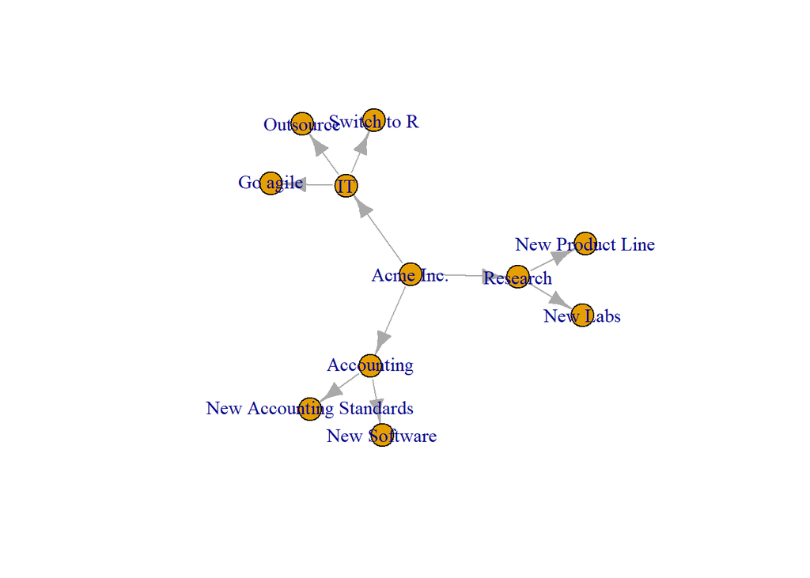

```r
plot(as.igraph(acme, directed = TRUE, direction = "climb"))
```

```r
# Simple network diagram:
acmeNetwork <- ToDataFrameNetwork(acme, "name")
simpleNetwork(acmeNetwork[-3], fontSize = 12)
```

[interactive chart not shown]

```r
# Radial Network diagram:
useRtreeList <- ToListExplicit( acme, unname = TRUE )
radialNetwork( useRtreeList )
```

[interactive chart not shown]

# Converting a data.tree to an R data.frame or list

In order to do predictive modelling or analysis, it is useful to be able to convert the information in the *data.tree* structure to an R data.frame or list.

What follows below are a few different ways to do this:

```r
ToDataFrameTree(acme, "level", "cost", "p")
```

| levelName | level | cost | p |
| --- | --- | --- | --- |
| Acme Inc. | 1 | NA | NA |
| ¦--Accounting | 2 | NA | NA |
| ¦ ¦--New Software | 3 | 1000000 | 0.50 |
| ¦ °--New Accounting Standards | 3 | 500000 | 0.75 |
| ¦--Research | 2 | NA | NA |
| ¦ ¦--New Product Line | 3 | 2000000 | 0.25 |
| ¦ °--New Labs | 3 | 750000 | 0.90 |
| °--IT | 2 | NA | NA |
| ¦--Outsource | 3 | 400000 | 0.20 |
| ¦--Go agile | 3 | 250000 | 0.05 |

[output cut: 1 more lines]

```r
ToDataFrameTable(acme, "pathString", "cost", "p")
```

| pathString | cost | p |
| --- | --- | --- |
| Acme Inc./Accounting/New Software | 1000000 | 0.50 |
| Acme Inc./Accounting/New Accounting Standards | 500000 | 0.75 |
| Acme Inc./Research/New Product Line | 2000000 | 0.25 |
| Acme Inc./Research/New Labs | 750000 | 0.90 |
| Acme Inc./IT/Outsource | 400000 | 0.20 |
| Acme Inc./IT/Go agile | 250000 | 0.05 |
| Acme Inc./IT/Switch to R | 50000 | 1.00 |

Another way is:

```r
ToDataFrameNetwork(acme, "cost", "p")
```

|  | from | to | cost | p |
| --- | --- | --- | --- | --- |
| 1 | Acme Inc. | Accounting | NA | NA |
| 2 | Acme Inc. | Research | NA | NA |
| 3 | Acme Inc. | IT | NA | NA |
| 4 | Accounting | New Software | 1000000 | 0.50 |
| 5 | Accounting | New Accounting Standards | 500000 | 0.75 |
| 6 | Research | New Product Line | 2000000 | 0.25 |
| 7 | Research | New Labs | 750000 | 0.90 |
| 8 | IT | Outsource | 400000 | 0.20 |
| 9 | IT | Go agile | 250000 | 0.05 |
| 10 | IT | Switch to R | 50000 | 1.00 |

Another way is:

```r
ToDataFrameTypeCol(acme, "cost", "p")
```

| level_1 | level_2 | level_3 | cost | p |
| --- | --- | --- | --- | --- |
| Acme Inc. | Accounting | New Software | 1000000 | 0.50 |
| Acme Inc. | Accounting | New Accounting Standards | 500000 | 0.75 |
| Acme Inc. | Research | New Product Line | 2000000 | 0.25 |
| Acme Inc. | Research | New Labs | 750000 | 0.90 |
| Acme Inc. | IT | Outsource | 400000 | 0.20 |
| Acme Inc. | IT | Go agile | 250000 | 0.05 |
| Acme Inc. | IT | Switch to R | 50000 | 1.00 |

..or the *data.tree* can be converted to a nested list:

```r
as.list(acme) %>% str()
```

```
## List of 6
##  $ name      : chr "Acme Inc."
##  $ cost_all  : num 4950000
##  $ sum_cost  : num 4950000
##  $ Accounting:List of 4
##   ..$ cost_all                : num 1500000
##   ..$ sum_cost                : num 1500000
##   ..$ New Software            :List of 3
##   .. ..$ cost    : num 1e+06
##   .. ..$ cost_all: num 1e+06
##   .. ..$ p       : num 0.5
##   ..$ New Accounting Standards:List of 3
##   .. ..$ cost    : num 5e+05
##   .. ..$ cost_all: num 5e+05
##   .. ..$ p       : num 0.75
##  $ Research  :List of 4
##   ..$ cost_all        : num 2750000
##   ..$ sum_cost        : num 2750000
##   ..$ New Product Line:List of 3
##   .. ..$ cost    : num 2e+06
##   .. ..$ cost_all: num 2e+06
##   .. ..$ p       : num 0.25
##   ..$ New Labs        :List of 3
##   .. ..$ cost    : num 750000
##   .. ..$ cost_all: num 750000
##   .. ..$ p       : num 0.9
##  $ IT        :List of 5
##   ..$ cost_all   : num 7e+05
##   ..$ sum_cost   : num 7e+05
##   ..$ Outsource  :List of 3
##   .. ..$ cost    : num 4e+05
##   .. ..$ cost_all: num 4e+05
##   .. ..$ p       : num 0.2
##   ..$ Go agile   :List of 3
##   .. ..$ cost    : num 250000
##   .. ..$ cost_all: num 250000
##   .. ..$ p       : num 0.05
##   ..$ Switch to R:List of 3
##   .. ..$ cost    : num 50000
##   .. ..$ cost_all: num 50000
##   .. ..$ p       : num 1
```

# Labelling the levels of the tree

```r
acme
```

```
##                           levelName
## 1  Acme Inc.
## 2   ¦--Accounting
## 3   ¦   ¦--New Software
## 4   ¦   °--New Accounting Standards
## 5   ¦--Research
## 6   ¦   ¦--New Product Line
## 7   ¦   °--New Labs
## 8   °--IT
## 9       ¦--Outsource
## 10      ¦--Go agile
## 11      °--Switch to R
```

add 2 children to the Outsource node (Outsource is a child of IT):

```r
acme$IT$Outsource$AddChild("India")
acme$IT$Outsource$AddChild("Poland")

acme
```

```
##                           levelName
## 1  Acme Inc.
## 2   ¦--Accounting
## 3   ¦   ¦--New Software
## 4   ¦   °--New Accounting Standards
## 5   ¦--Research
## 6   ¦   ¦--New Product Line
## 7   ¦   °--New Labs
## 8   °--IT
## 9       ¦--Outsource
## 10      ¦   ¦--India
## 11      ¦   °--Poland
## 12      ¦--Go agile
## 13      °--Switch to R
```

iterate through the nodes in the acme tree,

```r
extract_levels <- acme$Get( "level", traversal="pre-order")
extract_levels
```

```
##                Acme Inc.               Accounting             New Software
##                        1                        2                        3
## New Accounting Standards                 Research         New Product Line
##                        3                        2                        3
##                 New Labs                       IT                Outsource
##                        3                        2                        3
##                    India                   Poland                 Go agile
##                        4                        4                        3
##              Switch to R
##                        3
```

```r
acme$Set( type = case_when( extract_levels==1 ~ "company (root)",
                            extract_levels==2 ~ "department",
                            extract_levels==3 ~ "project",
                            extract_levels==4 ~ "outsource_country",
                            TRUE ~ "error"
                          )
)

print( acme, "level", "type", "cost" )
```

```
##                           levelName level              type    cost
## 1  Acme Inc.                            1    company (root)      NA
## 2   ¦--Accounting                       2        department      NA
## 3   ¦   ¦--New Software                 3           project 1000000
## 4   ¦   °--New Accounting Standards     3           project  500000
## 5   ¦--Research                         2        department      NA
## 6   ¦   ¦--New Product Line             3           project 2000000
## 7   ¦   °--New Labs                     3           project  750000
## 8   °--IT                               2        department      NA
## 9       ¦--Outsource                    3           project  400000
## 10      ¦   ¦--India                    4 outsource_country      NA
## 11      ¦   °--Poland                   4 outsource_country      NA
## 12      ¦--Go agile                     3           project  250000
## 13      °--Switch to R                  3           project   50000
```

There are many ways to filter, prune and aggregate data.trees (see https://cran.r-project.org/web/packages/data.tree/vignettes/data.tree.html).

# creating a **data.tree** from a data.frame

```r
# this code taken from https://cran.r-project.org/web/packages/data.tree/vignettes/data.tree.html
data(GNI2014)
head(GNI2014)
```

|  | iso3 | country | continent | population | GNI |
| --- | --- | --- | --- | --- | --- |
| 3 | BMU | Bermuda | North America | 67837 | 106140 |
| 4 | NOR | Norway | Europe | 4676305 | 103630 |
| 5 | QAT | Qatar | Asia | 833285 | 92200 |
| 6 | CHE | Switzerland | Europe | 7604467 | 88120 |
| 7 | MAC | Macao SAR, China | Asia | 559846 | 76270 |
| 8 | LUX | Luxembourg | Europe | 491775 | 75990 |

We specify the tree structure by creating a column called *pathString*:

```r
GNI2014$pathString <- paste( "world",
                             GNI2014$continent,
                             GNI2014$country,
                             sep = "/"
                           )

GNI2014 %>% select( pathString, continent, country ) %>% head(10) %>% knitr::kable()
```

|  | pathString | continent | country |
| --- | --- | --- | --- |
| 3 | world/North America/Bermuda | North America | Bermuda |
| 4 | world/Europe/Norway | Europe | Norway |
| 5 | world/Asia/Qatar | Asia | Qatar |
| 6 | world/Europe/Switzerland | Europe | Switzerland |
| 7 | world/Asia/Macao SAR, China | Asia | Macao SAR, China |
| 8 | world/Europe/Luxembourg | Europe | Luxembourg |
| 10 | world/Oceania/Australia | Oceania | Australia |
| 11 | world/Europe/Sweden | Europe | Sweden |
| 12 | world/Europe/Denmark | Europe | Denmark |
| 14 | world/North America/United States | North America | United States |

```r
population <- as.Node(GNI2014)

print(population, "iso3", "population", "GNI", limit = 20)
```

```
##                                 levelName iso3 population    GNI
## 1  world                                               NA     NA
## 2   ¦--North America                                   NA     NA
## 3   ¦   ¦--Bermuda                         BMU      67837 106140
## 4   ¦   ¦--United States                   USA  313973000  55200
## 5   ¦   ¦--Canada                          CAN   33487208  51630
## 6   ¦   ¦--Bahamas, The                    BHS     309156  20980
## 7   ¦   ¦--Trinidad and Tobago             TTO    1310000  20070
## 8   ¦   ¦--Puerto Rico                     PRI    3971020  19310
## 9   ¦   ¦--Barbados                        BRB     284589  15310
## 10  ¦   ¦--St. Kitts and Nevis             KNA      40131  14920
## 11  ¦   ¦--Antigua and Barbuda             ATG      85632  13300
## 12  ¦   ¦--Panama                          PAN    3360474  11130
## 13  ¦   ¦--Costa Rica                      CRI    4253877  10120
## 14  ¦   ¦--Mexico                          MEX  111211789   9870
## 15  ¦   ¦--Grenada                         GRD      90739   7910
## 16  ¦   ¦--St. Lucia                       LCA     160267   7260
## 17  ¦   ¦--Dominica                        DMA      72660   6930
## 18  ¦   ¦--St. Vincent and the Grenadines  VCT     104574   6610
## 19  ¦   ¦--Dominican Republic              DOM    9650054   6040
## 20  ¦   °--... 7 nodes w/ 0 sub                        NA     NA
## 21  °--... 6 nodes w/ 171 sub                          NA     NA
```

```r
# see ?FromDataFrameTable for more details
```

Showcasing some tree-viewing options:

```r
print( population )
```

```
##                                  levelName
## 1   world
## 2    ¦--North America
## 3    ¦   ¦--Bermuda
## 4    ¦   ¦--United States
## 5    ¦   ¦--Canada
## 6    ¦   ¦--Bahamas, The
## 7    ¦   ¦--Trinidad and Tobago
## 8    ¦   ¦--Puerto Rico
## 9    ¦   ¦--Barbados
## 10   ¦   ¦--St. Kitts and Nevis
## 11   ¦   ¦--Antigua and Barbuda
## 12   ¦   ¦--Panama
## 13   ¦   ¦--Costa Rica
## 14   ¦   ¦--Mexico
```

[output cut: 87 more lines]

```r
print( population, limit = 8 )    # print top 8 rows
```

```
##                       levelName
## 1 world
## 2  ¦--North America
## 3  ¦   ¦--Bermuda
## 4  ¦   ¦--United States
## 5  ¦   ¦--Canada
## 6  ¦   ¦--Bahamas, The
## 7  ¦   ¦--Trinidad and Tobago
## 8  ¦   °--... 19 nodes w/ 0 sub
## 9  °--... 6 nodes w/ 183 sub
```

```r
print( population, limit = 4 )    # print top 4 rows
```

```
##                       levelName
## 1 world
## 2  ¦--North America
## 3  ¦   ¦--Bermuda
## 4  ¦   °--... 23 nodes w/ 0 sub
## 5  °--... 6 nodes w/ 187 sub
```